# 36-315 Lecture 07, Fall 2016

Sam Ventura

September 21, 2016

# Interpretting Mosaic Plots

```r
library(data.table)
bike_data <- fread("https://raw.githubusercontent.com/sventura/315-code-and-datasets/master/data/nyc-citi-bike-data-subset.csv")

library(reshape2)
library(dplyr)
date_time <- colsplit(bike_data$starttime, " ", c("date", "time"))
bike_data <- mutate(bike_data,
                    birth_decade = paste0(substr(`birth year`, 1, 3), "0s"),
                    date = as.vector(date_time$date),
                    time_of_day = as.vector(date_time$time),
                    hour_of_day = substr(time_of_day, 1, 2),
                    am_or_pm = ifelse(as.integer(hour_of_day) < 12, "AM", "PM"),
                    day_of_week = weekdays(as.Date(date, format = "%m/%d/%Y")),
                    less_than_30_mins = ifelse(tripduration < 1800, "Short Trip", "Long Trip"),
                    weekend = ifelse(day_of_week %in% c("Saturday", "Sunday"), "Weekend", "Weekday"))
```

# Mosaic Plot – No Association

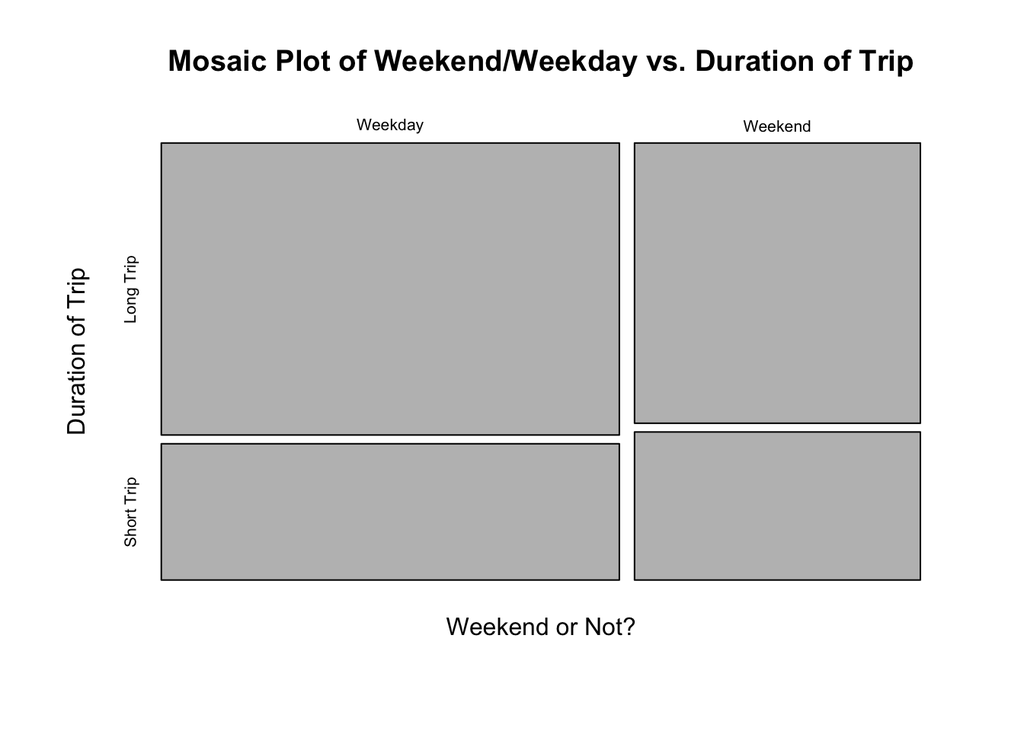

```r
tab <- table(bike_data$weekend, bike_data$less_than_30_mins)
mosaicplot(tab, xlab = "Weekend or Not?", ylab = "Duration of Trip",
           main = "Mosaic Plot of Weekend/Weekday vs. Duration of Trip")
```

- The marginal distribution of the first variable (`weekend`) is shown with the column widths.
- The conditional distribution of the second variable (`less_than_30_mins`) is shown with the heights of the boxes.
- The area of the boxes shows the joint distribution of the two variables.
- Let’s add some color to see if there’s an association.

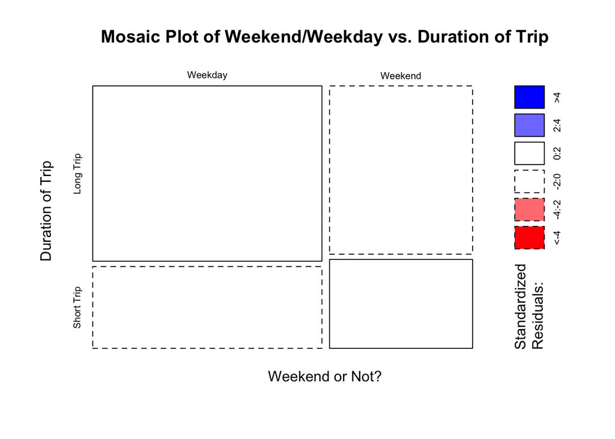

```r
mosaicplot(tab, xlab = "Weekend or Not?", ylab = "Duration of Trip",
           main = "Mosaic Plot of Weekend/Weekday vs. Duration of Trip", shade = T)
```

Okay, here’s how to read mosaic plots, in general:

- The colors correspond to the standardized Pearson residuals (see notes from a few lectures ago).
- Red boxes indicate a large negative deviation from expected in the corresponding cell of the contingency table.
- Blue boxes indicate a large positive deviation from expected in the corresponding cell of the contingency table.
- White boxes indicate no deviation from expected in the corresponding cell of the contingency table.
- The darker the boxes, the larger the deviation from expected. Specifically, the light-colored boxes correspond to residuals between 2 and 4 (or -2 and -4). This means that we can reject the null hypothesis of independence at the alpha = 0.05 level (at least). The darker boxes correspond to residuals greater than 4 (or less than -4). This means that we can reject the null hypothesis of independence at the alpha = 0.0001 level (at least).
- **The cell outlines mean…?** The cell outlines indicate whether or not the residuals are positive or negative. This is especially helpfful for the colorblind, who can use this information to determine whether or not a shaded deviation from expected is positive or negative.

# Mosaic Plot – Associations!

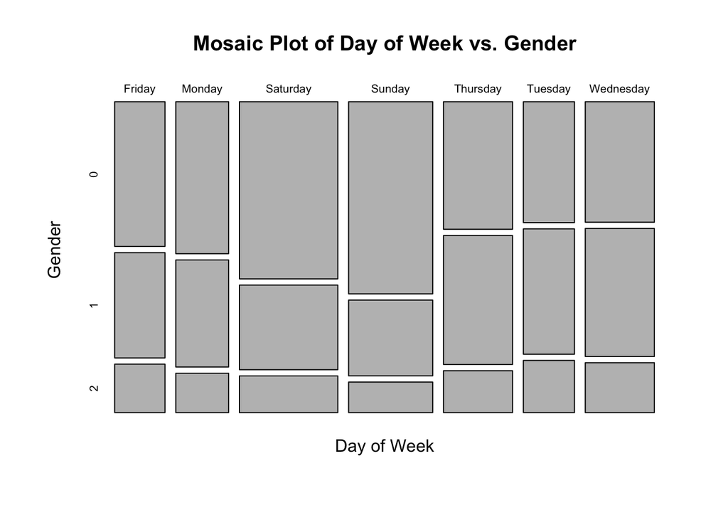

```r
tab <- table(bike_data$day_of_week, bike_data$gender)
mosaicplot(tab, xlab = "Day of Week", ylab = "Gender",
           main = "Mosaic Plot of Day of Week vs. Gender")
```

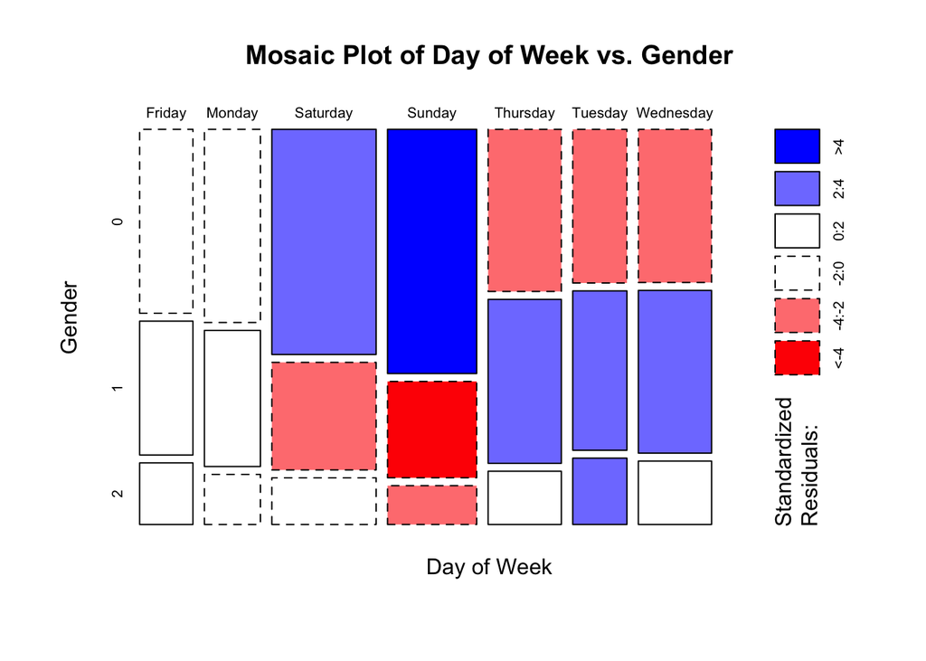

```r
mosaicplot(tab, xlab = "Day of Week", ylab = "Gender",
           main = "Mosaic Plot of Day of Week vs. Gender", shade = T)
```

**What’s happening here?**

# Mosaic Plot – More Associations!

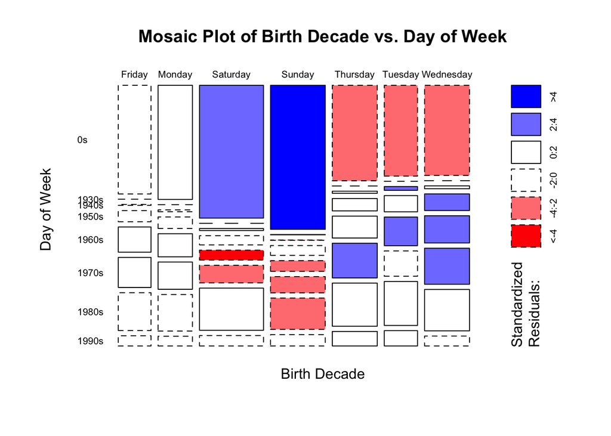

```r
tab <- table(bike_data$day_of_week, bike_data$birth_decade)
mosaicplot(tab, xlab = "Birth Decade", ylab = "Day of Week",
           main = "Mosaic Plot of Birth Decade vs. Day of Week", shade = T, las = 1)
```

**When we see a horizontal line in place of a cell, what does this mean?**

# Mosaic Plot – When Can We Reject The Null Hypothesis?

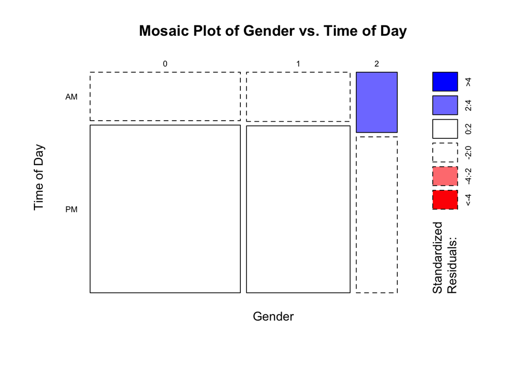

```r
tab <- table(bike_data$gender, bike_data$am_or_pm)
mosaicplot(tab, xlab = "Gender", ylab = "Time of Day",
           main = "Mosaic Plot of Gender vs. Time of Day", shade = T, las = 1)
```

Even if only one cell has a significantly larger or smaller than expected standardized Pearson residual, we can reject the null hypothesis of indepdendence!

# Mosaic Plot – When Do We Fail To Reject The Null Hypothesis?

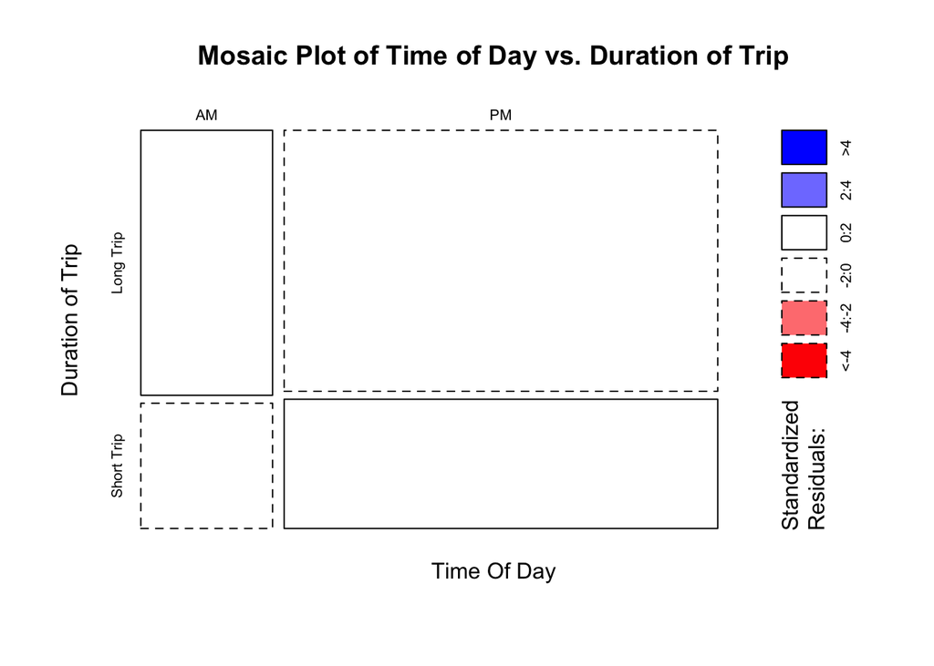

```r
tab <- table(bike_data$am_or_pm, bike_data$less_than_30_mins)
mosaicplot(tab, xlab = "Time Of Day", ylab = "Duration of Trip",
           main = "Mosaic Plot of Time of Day vs. Duration of Trip", shade = T)
```

Only if all cells are white, we do not have evidence to reject the null hypothesis of indepdendence!

# Friday: Mosaic Plots with `ggplot()`

# HW04: Extending Mosaic Plot Benefits to Bar Charts